# map501_F416781

2024-11-25

## Setting up

```r
knitr::opts_chunk$set(
 results = "hold", echo = TRUE, eval = TRUE,
 message = FALSE, fig.width = 7,
 fig.height = 4, fig.align = "center"
)
```

## Installing needed

```
## [1] "All specified libraries have been installed and loaded."
```

## Loading libraries to be used

```r
library("tidyverse")
 library("magrittr")
 library("here")
 library("janitor")
 library("gridExtra")
 library("readxl")
 library("Lahman")
 library("viridis")
 library("lindia")
 library("lme4")
 library("caret")
 library("pROC")
 library("car")
```

### 1. Linear Regression

1. Creating df_managers with win_pct and selected variables

```r
# Create the df_managers dataset
df_managers <- Managers %>%
  mutate(win_pct = W / G) %>%
  select(playerID, teamID, yearID, lgID, plyrMgr, win_pct)

# Check the structure of df_managers
str(df_managers)
```

```
## 'data.frame':    3749 obs. of  6 variables:
##  $ playerID: chr  "wrighha01" "woodji01" "paborch01" "lennobi01" ...
##  $ teamID  : Factor w/ 149 levels "ALT","ANA","ARI",..: 24 31 39 56 56 90 97 111 136 136 ...
##  $ yearID  : int  1871 1871 1871 1871 1871 1871 1871 1871 1871 1871 ...
##  $ lgID    : Factor w/ 7 levels "AA","AL","FL",..: 4 4 4 4 4 4 4 4 4 4 ...
##  $ plyrMgr : Factor w/ 2 levels "N","Y": 2 2 2 2 2 2 2 2 2 2 ...
##  $ win_pct : num  0.645 0.679 0.345 0.357 0.4 ...
```

##b. Create awards_man dataset i. Create df_teams

```r
df_teams <- Teams %>%
  select(yearID, teamID, DivWin, CS)

# Check the structure of df_teams
str(df_teams)
```

```
## 'data.frame':    3045 obs. of  4 variables:
##  $ yearID: int  1871 1871 1871 1871 1871 1871 1871 1871 1871 1872 ...
##  $ teamID: Factor w/ 149 levels "ALT","ANA","ARI",..: 24 31 39 56 90 97 111 136 142 8 ...
##  $ DivWin: chr  NA NA NA NA ...
##  $ CS    : int  16 21 8 4 15 12 10 24 13 18 ...
```

## ii. Create man_teams by merging df_managers with df_teams and remove lgID

```r
man_teams <- merge(df_managers, df_teams, by = c("yearID", "teamID")) %>%
  select(-lgID)

# Check the structure of man_teams
str(man_teams)
```

```
## 'data.frame':    3749 obs. of  7 variables:
##  $ yearID  : int  1871 1871 1871 1871 1871 1871 1871 1871 1871 1871 ...
##  $ teamID  : Factor w/ 149 levels "ALT","ANA","ARI",..: 24 31 39 56 56 90 97 111 136 136 ...
##  $ playerID: chr  "wrighha01" "woodji01" "paborch01" "lennobi01" ...
##  $ plyrMgr : Factor w/ 2 levels "N","Y": 2 2 2 2 2 2 2 2 2 2 ...
##  $ win_pct : num  0.645 0.679 0.345 0.357 0.4 ...
##  $ DivWin  : chr  NA NA NA NA ...
##  $ CS      : int  16 21 8 4 4 15 12 10 24 24 ...
```

## iii. Merge man_teams with AwardsShareManagers to create awards_man

```r
awards_man <- merge(man_teams, AwardsShareManagers, by = c("yearID", "playerID"))

# Check the structure of awards_man
str(awards_man)
```

```
## 'data.frame':    511 obs. of  12 variables:
##  $ yearID    : int  1983 1983 1983 1983 1983 1983 1983 1984 1984 1984 ...
##  $ playerID  : chr  "altobjo01" "coxbo01" "larusto01" "lasorto01" ...
##  $ teamID    : Factor w/ 149 levels "ALT","ANA","ARI",..: 5 134 33 72 58 102 106 52 134 35 ...
##  $ plyrMgr   : Factor w/ 2 levels "N","Y": 1 1 1 1 1 1 1 1 1 1 ...
##  $ win_pct   : num  0.605 0.549 0.611 0.558 0.525 ...
##  $ DivWin    : chr  "Y" "N" "Y" "Y" ...
##  $ CS        : int  33 72 50 76 95 75 77 68 67 66 ...
##  $ awardID   : chr  "BBWAA Manager of the Year" "BBWAA Manager of the Year" "BBWAA Manager of the Year" "BBWAA Manager of the Year" ...
##  $ lgID      : Factor w/ 2 levels "AL","NL": 1 1 1 2 2 2 2 1 1 2 ...
##  $ pointsWon : int  7 4 17 10 9 1 4 96 9 101 ...
##  $ pointsMax : int  28 28 28 24 24 24 24 140 140 120 ...
##  $ votesFirst: int  7 4 17 10 9 1 4 13 0 16 ...
```

## iv. Add sqr_point_pct to awards_man

```r
awards_man <- awards_man %>%
  mutate(sqr_point_pct = sqrt(pointsWon / pointsMax))
```

## v. Remove incomplete cases and drop unused levels of teamID

```r
awards_man <- awards_man %>%
  na.omit() %>%
  droplevels()

# Check the cleaned awards_man dataset
str(awards_man)
```

```
## 'data.frame':    486 obs. of  13 variables:
##  $ yearID       : int  1983 1983 1983 1983 1983 1983 1983 1984 1984 1984 ...
##  $ playerID     : chr  "altobjo01" "coxbo01" "larusto01" "lasorto01" ...
##  $ teamID       : Factor w/ 35 levels "ANA","ARI","ATL",..: 4 34 7 17 14 26 27 12 34 8 ...
##  $ plyrMgr      : Factor w/ 2 levels "N","Y": 1 1 1 1 1 1 1 1 1 1 ...
##  $ win_pct      : num  0.605 0.549 0.611 0.558 0.525 ...
##  $ DivWin       : chr  "Y" "N" "Y" "Y" ...
##  $ CS           : int  33 72 50 76 95 75 77 68 67 66 ...
##  $ awardID      : chr  "BBWAA Manager of the Year" "BBWAA Manager of the Year" "BBWAA Manager of the Year" "BBWAA Manager of the Year" ...
##  $ lgID         : Factor w/ 2 levels "AL","NL": 1 1 1 2 2 2 2 1 1 2 ...
##  $ pointsWon    : int  7 4 17 10 9 1 4 96 9 101 ...
##  $ pointsMax    : int  28 28 28 24 24 24 24 140 140 120 ...
##  $ votesFirst   : int  7 4 17 10 9 1 4 13 0 16 ...
##  $ sqr_point_pct: num  0.5 0.378 0.779 0.645 0.612 ...
##  - attr(*, "na.action")= 'omit' Named int [1:25] 123 124 125 126 127 128 129 130 131 132 ...
##   ..- attr(*, "names")= chr [1:25] "123" "124" "125" "126" ...
```

## c. Fit Gaussian model spp_mod

```r
# Fit the model
spp_mod <- lm(sqr_point_pct ~ win_pct + DivWin + CS, data = awards_man)

# Summarize the results
summary(spp_mod)
```

```
##
## Call:
## lm(formula = sqr_point_pct ~ win_pct + DivWin + CS, data = awards_man)
##
## Residuals:
##      Min       1Q   Median       3Q      Max
## -0.52249 -0.18946 -0.03539  0.18009  0.66465
##
## Coefficients:
##               Estimate Std. Error t value Pr(>|t|)
## (Intercept) -0.7278773  0.1409811  -5.163 3.56e-07 ***
## win_pct      1.8083774  0.2518894   7.179 2.67e-12 ***
## DivWinY      0.1364128  0.0266417   5.120 4.42e-07 ***
## CS           0.0027219  0.0006249   4.356 1.62e-05 ***
## ---
## Signif. codes:  0 '***' 0.001 '**' 0.01 '*' 0.05 '.' 0.1 ' ' 1
##
## Residual standard error: 0.2401 on 482 degrees of freedom
## Multiple R-squared:  0.271,  Adjusted R-squared:  0.2665
## F-statistic: 59.74 on 3 and 482 DF,  p-value: < 2.2e-16
```

The linear regression model predicts sqr_point_pct using win_pct, DivWin, and CS as predictors. The fitted model is:

```
    sqr_point_pct = -0.73 + 1.81*win_pct + 0.14*DivWinY + 0.003*CS
```

Intercept: The intercept (-0.73) indicates the baseline value of sqr_point_pct when all predictors are zero. While not directly meaningful in this context, it provides a reference point for the model.

win_pct: For every unit increase in win_pct, the sqr_point_pct is expected to increase by 1.81, holding other variables constant. This effect is highly significant (p-value = 2.67e-12), showing a strong positive relationship.

DivWin: Teams that win their division (DivWinY = 1) have an average sqr_point_pct that is 0.14 higher than those that do not (DivWinY = 0), controlling for other factors. This relationship is also highly significant (p-value = 4.42e-07).

CS: Each additional unit of CS corresponds to an increase of 0.003 in sqr_point_pct, with a highly significant p-value of 1.62e-05. Although the effect is small, it is statistically important.

Model fit: The model explains 27.1% of the variance in sqr_point_pct (Multiple R-squared = 0.271). The residual standard error is 0.2401, suggesting the model fits the data reasonably well.

##d. Evaluate model assumptions

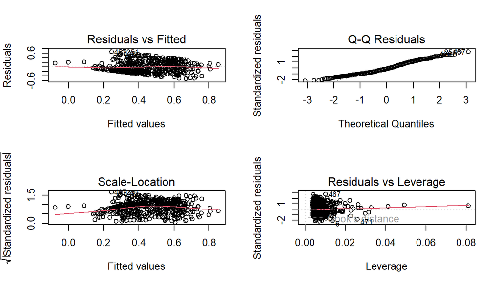

```r
# Plot residuals to check assumptions
par(mfrow = c(2, 2))
plot(spp_mod)
```

```r
# Check for multicollinearity
library(car)
vif(spp_mod)
```

```
##  win_pct   DivWin       CS
## 1.491421 1.467156 1.024769
```

```r
# Create new data for prediction
new_data <- data.frame(
  win_pct = 0.8,
  DivWin = factor("Yes", levels = levels(awards_man$DivWin)),
  CS = 8
)

# Predict the expected value
predicted_value <- predict(spp_mod, new_data)
predicted_value
```

```
##  1
## NA
```

## f. Construct 95% confidence intervals for parameter estimates

```r
# Confidence intervals
conf_intervals <- confint(spp_mod, level = 0.95)
conf_intervals
```

```
##                    2.5 %       97.5 %
## (Intercept) -1.004890669 -0.450863854
## win_pct      1.313440582  2.303314302
## DivWinY      0.084064590  0.188760923
## CS           0.001493985  0.003949758
```

### 2. Logistic Regression

##a. Plot plyrMgr Against yearID

[figure not shown]

```r
# Jitter the points vertically to visualize plyrMgr vs. yearID
ggplot(df_managers, aes(x = yearID, y = as.numeric(plyrMgr))) +
  geom_jitter(height = 0.2, width = 0, color = "blue", alpha = 0.6) +
  scale_y_continuous(breaks = c(0, 1), labels = c("Not Player-Manager", "Player-Manager")) +
  labs(title = "Player-Manager Status Over Time", x = "Year", y = "Player-Manager Status") +
  theme_minimal()
```

Comment: The graph may show a decline in player-managers over time as specialization in the manager role increased.

##b.Fitting Logistic Regression Model

```r
# Logistic regression for plyrMgr as a function of yearID
logit_model <- glm(plyrMgr ~ yearID, data = df_managers, family = "binomial")

# Summarize the model
summary(logit_model)

# Report and interpret results
# Formula: log(odds) = β0 + β1 * yearID
# Extract and round coefficients
rounded_coefs <- round(coef(logit_model), 2)

# Print the rounded coefficients
rounded_coefs
```

```
##
## Call:
## glm(formula = plyrMgr ~ yearID, family = "binomial", data = df_managers)
##
## Coefficients:
##              Estimate Std. Error z value Pr(>|z|)
## (Intercept) 88.604237   3.412071   25.97   <2e-16 ***
## yearID      -0.046611   0.001779  -26.19   <2e-16 ***
## ---
## Signif. codes:  0 '***' 0.001 '**' 0.01 '*' 0.05 '.' 0.1 ' ' 1
##
## (Dispersion parameter for binomial family taken to be 1)
##
##     Null deviance: 3442.4  on 3748  degrees of freedom
## Residual deviance: 2127.7  on 3747  degrees of freedom
## AIC: 2131.7
##
## Number of Fisher Scoring iterations: 6
##
## (Intercept)      yearID
##       88.60       -0.05
```

The logistic regression model predicts the probability of being a player-manager (plyrMgr) based on the year (yearID). The fitted equation is:  
{logit}(p) = 88.60 - 0.05*{yearID}

where p is the probability of a manager being a player.

The yearID coefficient (-0.05, p < 2e-16) indicates that each passing year decreases the log-odds of being a player-manager by 0.05. This corresponds to a 5% reduction in odds per year (e^{-0.05} approximately equal to 0.95), showing a significant decline in the prevalence of player-managers over time.

The model significantly reduces variability, as seen in the drop from a null deviance of 3442.4 to a residual deviance of 2127.7, with an AIC of 2131.7, suggesting a good fit. This supports the conclusion that being a player-manager has become increasingly rare over time.

##c. Checking for Overfitting Using 80%-20% Split

```r
set.seed(123)
train_indices <- sample(seq_len(nrow(df_managers)), size = 0.8 * nrow(df_managers))
train_data <- df_managers[train_indices, ]
test_data <- df_managers[-train_indices, ]
```

##Fit Model on Training Data

```r
train_model <- glm(plyrMgr ~ yearID, data = train_data, family = "binomial")
```

##ROC Curves

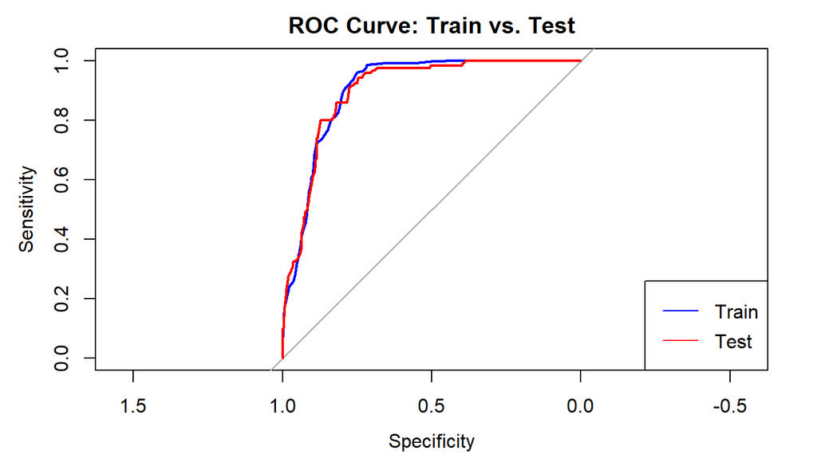

```r
library(pROC)

# Predict probabilities for training and testing data
train_probs <- predict(train_model, newdata = train_data, type = "response")
test_probs <- predict(train_model, newdata = test_data, type = "response")

# Generate ROC curves
roc_train <- roc(train_data$plyrMgr, train_probs)
roc_test <- roc(test_data$plyrMgr, test_probs)

# Plot ROC curves
plot(roc_train, col = "blue", main = "ROC Curve: Train vs. Test")
plot(roc_test, col = "red", add = TRUE)
legend("bottomright", legend = c("Train", "Test"), col = c("blue", "red"), lty = 1)
```